# Biodiversity Analysis

Andrea Martinez

2024-04-24

# Setting the Environment

## Set the seed

```r
set.seed(238428)
```

## Load Libraries

```r
pacman::p_load(tidyverse, devtools, patchwork, iNEXT, phyloseq,
               install = FALSE)
```

## Load in Data

```r
load("data/02_PreProcessing/raw_preprocessed_physeq.RData")
raw_preprocessed_physeq
```

```
## phyloseq-class experiment-level object
## otu_table()   OTU Table:         [ 31492 taxa and 35 samples ]
## sample_data() Sample Data:       [ 35 samples by 12 sample variables ]
## tax_table()   Taxonomy Table:    [ 31492 taxa by 9 taxonomic ranks ]
```

```r
# Intiution Check
min(sample_sums(raw_preprocessed_physeq))
```

```
## [1] 17544
```

```r
metadata_df <-
  raw_preprocessed_physeq %>%
  sample_data() %>%
  data.frame()

#Make n_level a column of characters to enable merge with n_colors
metadata_df$n_level <- as.character(metadata_df$n_level)

#Make growth_stage a column of characters to enable merge with growth_stage_colors
metadata_df$growth_stage <- as.character(metadata_df$growth_stage)

head(metadata_df)
```

```
##                   names   planted n_level growth_stage rep input filtered
## SRR21916202 SRR21916202 Unplanted       0           75   1 84301    72757
## SRR21916203 SRR21916203 Unplanted     300           30   3 90262    78653
## SRR21916205 SRR21916205 Unplanted     300           30   1 98609    85375
## SRR21916206 SRR21916206 Unplanted     150           30   3 98699    85615
## SRR21916207 SRR21916207 Unplanted     150           30   2 95172    82622
## SRR21916208 SRR21916208   Planted     300           75   3 92237    79185
##             denoisedF denoisedR merged nochim perc_reads_retained
## SRR21916202     63336     65789  35826  29386            34.85842
## SRR21916203     70184     72774  46001  38767            42.94941
## SRR21916205     77532     79587  50008  42868            43.47271
## SRR21916206     76055     78373  45951  37728            38.22531
## SRR21916207     72670     75130  42658  35255            37.04346
## SRR21916208     69693     72204  39858  30898            33.49849
```

```r
# Setting colors for Nitrogen levels
n_colors <- c (
  "0" = "#D9CC3C",
 "150" = "#A0E0BA",
 "300" = "coral2")


growth_stage_colors <- c (
  "30" = "lightblue",
  "75" = "darkblue")

planted_colors <- c (
  "Unplanted" = "springgreen",
  "Planted" = "purple")
```

# Goals

1. Calculate the Hill Diversity of the samples.
2. Evaluate the rarefaction curves.
3. Evaluate the Diversity values.
4. Makes notes of specific samples and their seq depth.

# Diversity Calculations with iNEXT

```r
# prepare input data
iNEXT_input_df <-
  raw_preprocessed_physeq %>%
  otu_table() %>%
  data.frame()
# Quick check
dim(iNEXT_input_df)
```

```
## [1] 31492    35
```

```r
# Run iNEXT: Calculate the Hill Numbers
# Note that: Species in ROWS, Samples in COLUMNS
# Remember to set the seed!
#iNEXT_data <- iNEXT(iNEXT_input_df,
#                   q = c(0,1,2), datatype = "abundance")

#Save the file
#save(iNEXT_data, file = "data/04_Biodiversity/iNEXT_data.RData")
```

# Evaluate the Diversity!

```r
load("data/04_Biodiversity/iNEXT_data.RData")
str(iNEXT_data)
```

```
## List of 3
##  $ DataInfo:'data.frame':    35 obs. of  14 variables:
##   ..$ Assemblage: chr [1:35] "SRR21916202" "SRR21916203" "SRR21916205" "SRR21916206" ...
##   ..$ n         : num [1:35] 29262 38724 42738 37619 35134 ...
##   ..$ S.obs     : num [1:35] 2060 2023 2010 2225 2200 ...
##   ..$ SC        : num [1:35] 0.996 0.996 0.996 0.996 0.996 ...
##   ..$ f1        : num [1:35] 132 138 152 161 145 121 162 112 119 154 ...
##   ..$ f2        : num [1:35] 390 276 278 347 399 375 281 377 337 273 ...
##   ..$ f3        : num [1:35] 260 214 185 253 281 235 205 236 221 211 ...
##   ..$ f4        : num [1:35] 134 123 131 149 142 130 130 128 123 109 ...
##   ..$ f5        : num [1:35] 103 93 83 133 106 97 75 98 87 88 ...
##   ..$ f6        : num [1:35] 105 92 96 93 80 78 65 97 78 65 ...
##   ..$ f7        : num [1:35] 79 77 68 90 83 68 78 69 70 55 ...
##   ..$ f8        : num [1:35] 78 76 59 69 79 80 55 63 53 54 ...
##   ..$ f9        : num [1:35] 53 61 43 81 60 53 55 55 52 53 ...
##   ..$ f10       : num [1:35] 63 43 52 60 48 46 44 44 47 52 ...
##  $ iNextEst:List of 2
##   ..$ size_based    :'data.frame':   4200 obs. of  10 variables:
##   .. ..$ Assemblage: chr [1:4200] "SRR21916202" "SRR21916202" "SRR21916202" "SRR21916202" ...
##   .. ..$ m         : num [1:4200] 1 1626 3252 4877 6503 ...
##   .. ..$ Method    : chr [1:4200] "Rarefaction" "Rarefaction" "Rarefaction" "Rarefaction" ...
##   .. ..$ Order.q   : num [1:4200] 0 0 0 0 0 0 0 0 0 0 ...
##   .. ..$ qD        : num [1:4200] 1 762 1094 1303 1454 ...
##   .. ..$ qD.LCL    : num [1:4200] 1 757 1085 1292 1441 ...
##   .. ..$ qD.UCL    : num [1:4200] 1 767 1102 1315 1467 ...
##   .. ..$ SC        : num [1:4200] 0.00254 0.72881 0.84378 0.89272 0.91984 ...
##   .. ..$ SC.LCL    : num [1:4200] 0.00245 0.72593 0.84147 0.89081 0.91827 ...
##   .. ..$ SC.UCL    : num [1:4200] 0.00263 0.73169 0.8461 0.89463 0.92142 ...
##   ..$ coverage_based:'data.frame':   4200 obs. of  8 variables:
##   .. ..$ Assemblage: chr [1:4200] "SRR21916202" "SRR21916202" "SRR21916202" "SRR21916202" ...
##   .. ..$ SC        : num [1:4200] 0.00254 0.72881 0.84378 0.89272 0.91984 ...
##   .. ..$ m         : num [1:4200] 1 1626 3252 4877 6503 ...
##   .. ..$ Method    : chr [1:4200] "Rarefaction" "Rarefaction" "Rarefaction" "Rarefaction" ...
##   .. ..$ Order.q   : num [1:4200] 0 0 0 0 0 0 0 0 0 0 ...
##   .. ..$ qD        : num [1:4200] 1 762 1094 1303 1454 ...
##   .. ..$ qD.LCL    : num [1:4200] 0.987 751.292 1078.714 1285.329 1433.869 ...
##   .. ..$ qD.UCL    : num [1:4200] 1.01 773 1109.01 1321.65 1474.22 ...
##  $ AsyEst  :'data.frame':    105 obs. of  7 variables:
##   ..$ Assemblage: chr [1:105] "SRR21916202" "SRR21916202" "SRR21916202" "SRR21916203" ...
##   ..$ Diversity : chr [1:105] "Species richness" "Shannon diversity" "Simpson diversity" "Species richness" ...
##   ..$ Observed  : num [1:105] 2060 868 388 2023 759 ...
##   ..$ Estimator : num [1:105] 2082 901 394 2057 781 ...
##   ..$ s.e.      : num [1:105] 18.77 6.11 6.35 18.83 5.26 ...
##   ..$ LCL       : num [1:105] 2060 889 381 2023 770 ...
##   ..$ UCL       : num [1:105] 2119 913 406 2094 791 ...
##  - attr(*, "class")= chr "iNEXT"
```

```r
typeof(iNEXT_data)
```

```
## [1] "list"
```

# Plot Diversity

```r
# Prepare Colors
color_df <-
  iNEXT_input_df %>%
  colnames() %>%
  data.frame()
# Check
head(color_df)
```

```
##             .
## 1 SRR21916202
## 2 SRR21916203
## 3 SRR21916205
## 4 SRR21916206
## 5 SRR21916207
## 6 SRR21916208
```

```r
# Rename the column
colnames(color_df)[1] <- "names"
# Check
head(color_df)
```

```
##         names
## 1 SRR21916202
## 2 SRR21916203
## 3 SRR21916205
## 4 SRR21916206
## 5 SRR21916207
## 6 SRR21916208
```

```r
# Make a helper dataframe for plotting with colors

iNEXT_color_df <-
  color_df %>%
  # Merge with metadata
  left_join(metadata_df, by = "names") %>%
  # Merge with colors for plotting with ggiNEXT
  left_join(data.frame(n_colors = n_colors,
            n_level = names(n_colors)),
            by = "n_level")

iNEXT_color_df_2 <-
  color_df %>%
  # Merge with metadata
  left_join(metadata_df, by = "names") %>%
  # Merge with colors for plotting with ggiNEXT
  left_join(data.frame(growth_stage_colors = growth_stage_colors,
            growth_stage = names(growth_stage_colors)),
            by = "growth_stage")

iNEXT_color_df_3 <-
  color_df %>%
  # Merge with metadata
  left_join(metadata_df, by = "names") %>%
  # Merge with colors for plotting with ggiNEXT
  left_join(data.frame(planted_colors = planted_colors,
            planted = names(planted_colors)),
            by = "planted")
```

# Plot Rarefaction with `ggiNEXT`

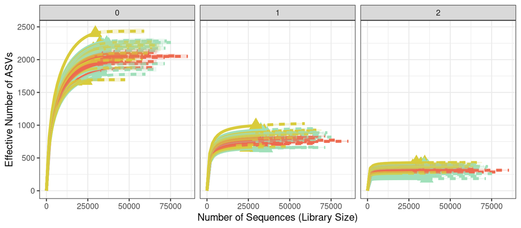

```r
# Plot rarefaction!
# rarefaction/extrapolation curve, type = 1

# Order q:
  # 0 = Richness/ Number of Total taxa
  # 1 = Exponential Shannon / Number of "Common" taxa
  # 2 = Inverse Simpson / Number of "Dominant" taxa

ggiNEXT(iNEXT_data, type = 1, facet.var = "Order.q") +
  facet_wrap(~Order.q, scales = "fixed") +
  scale_color_manual(values = iNEXT_color_df$n_colors, guide = FALSE) +
  scale_fill_manual(values = iNEXT_color_df$n_colors, guide = FALSE) +
  scale_shape_manual(values = base::rep(17, nsamples(raw_preprocessed_physeq)),
                     guide = FALSE) +
  labs(x = "Number of Sequences (Library Size)",
       y = "Effective Number of ASVs") +
  theme_bw() +
  theme(legend.position = "none")
```

Remembering that an Order q of:

- 0 = Richness/ Number of Total taxa
- 1 = Exponential Shannon / Number of “Common” taxa
- 2 = Inverse Simpson / Number of “Dominant” taxa

*iNEXT will extrapolate the number of sequences to double the sequencing depth of the sample!*

Conclusions from the plot above:  
With increasing weight on abundance, (q = 0,1,2), there is an earlier plateau in the # of ASVs with increasing sequencing depth. This shows that the most highly abundant species are identifiable in early rounds of sequencing due to their high presence. One sample has noticeably higher species richness.

# Manually plot Diversity

## Rarefaction

```r
iNEXT_manual_df <-
  iNEXT_data$iNextEst$size_based %>%
  dplyr::rename(names = Assemblage) %>%
  # join with metadata
  left_join(., metadata_df, by = "names") %>%
  # Add colors to data frame
  left_join(., data.frame(n_colors = n_colors,
                          n_level= names(n_colors)),
            by = "n_level")
# Inspect
dim(iNEXT_manual_df)
```

```
## [1] 4200   22
```

```r
str(iNEXT_manual_df)
```

```
## 'data.frame':    4200 obs. of  22 variables:
##  $ names              : chr  "SRR21916202" "SRR21916202" "SRR21916202" "SRR21916202" ...
##  $ m                  : num  1 1626 3252 4877 6503 ...
##  $ Method             : chr  "Rarefaction" "Rarefaction" "Rarefaction" "Rarefaction" ...
##  $ Order.q            : num  0 0 0 0 0 0 0 0 0 0 ...
##  $ qD                 : num  1 762 1094 1303 1454 ...
##  $ qD.LCL             : num  1 757 1085 1292 1441 ...
##  $ qD.UCL             : num  1 767 1102 1315 1467 ...
##  $ SC                 : num  0.00254 0.72881 0.84378 0.89272 0.91984 ...
##  $ SC.LCL             : num  0.00245 0.72593 0.84147 0.89081 0.91827 ...
##  $ SC.UCL             : num  0.00263 0.73169 0.8461 0.89463 0.92142 ...
##  $ planted            : chr  "Unplanted" "Unplanted" "Unplanted" "Unplanted" ...
##  $ n_level            : chr  "0" "0" "0" "0" ...
##  $ growth_stage       : chr  "75" "75" "75" "75" ...
##  $ rep                : int  1 1 1 1 1 1 1 1 1 1 ...
##  $ input              : num  84301 84301 84301 84301 84301 ...
##  $ filtered           : num  72757 72757 72757 72757 72757 ...
##  $ denoisedF          : num  63336 63336 63336 63336 63336 ...
##  $ denoisedR          : num  65789 65789 65789 65789 65789 ...
##  $ merged             : num  35826 35826 35826 35826 35826 ...
##  $ nochim             : num  29386 29386 29386 29386 29386 ...
##  $ perc_reads_retained: num  34.9 34.9 34.9 34.9 34.9 ...
##  $ n_colors           : chr  "#D9CC3C" "#D9CC3C" "#D9CC3C" "#D9CC3C" ...
```

```r
iNEXT_manual_df_2 <-
  iNEXT_data$iNextEst$size_based %>%
  dplyr::rename(names = Assemblage) %>%
  # join with metadata
  left_join(., metadata_df, by = "names") %>%
  # Add colors to data frame
  left_join(., data.frame(growth_stage_colors = growth_stage_colors,
                          growth_stage = names(growth_stage_colors)),
            by = "growth_stage")
# Inspect
dim(iNEXT_manual_df_2)
```

```
## [1] 4200   22
```

```r
str(iNEXT_manual_df_2)
```

```
## 'data.frame':    4200 obs. of  22 variables:
##  $ names              : chr  "SRR21916202" "SRR21916202" "SRR21916202" "SRR21916202" ...
##  $ m                  : num  1 1626 3252 4877 6503 ...
##  $ Method             : chr  "Rarefaction" "Rarefaction" "Rarefaction" "Rarefaction" ...
##  $ Order.q            : num  0 0 0 0 0 0 0 0 0 0 ...
##  $ qD                 : num  1 762 1094 1303 1454 ...
##  $ qD.LCL             : num  1 757 1085 1292 1441 ...
##  $ qD.UCL             : num  1 767 1102 1315 1467 ...
##  $ SC                 : num  0.00254 0.72881 0.84378 0.89272 0.91984 ...
##  $ SC.LCL             : num  0.00245 0.72593 0.84147 0.89081 0.91827 ...
##  $ SC.UCL             : num  0.00263 0.73169 0.8461 0.89463 0.92142 ...
##  $ planted            : chr  "Unplanted" "Unplanted" "Unplanted" "Unplanted" ...
##  $ n_level            : chr  "0" "0" "0" "0" ...
##  $ growth_stage       : chr  "75" "75" "75" "75" ...
##  $ rep                : int  1 1 1 1 1 1 1 1 1 1 ...
##  $ input              : num  84301 84301 84301 84301 84301 ...
##  $ filtered           : num  72757 72757 72757 72757 72757 ...
##  $ denoisedF          : num  63336 63336 63336 63336 63336 ...
##  $ denoisedR          : num  65789 65789 65789 65789 65789 ...
##  $ merged             : num  35826 35826 35826 35826 35826 ...
##  $ nochim             : num  29386 29386 29386 29386 29386 ...
##  $ perc_reads_retained: num  34.9 34.9 34.9 34.9 34.9 ...
##  $ growth_stage_colors: chr  "darkblue" "darkblue" "darkblue" "darkblue" ...
```

```r
iNEXT_manual_df_3 <-
  iNEXT_data$iNextEst$size_based %>%
  dplyr::rename(names = Assemblage) %>%
  # join with metadata
  left_join(., metadata_df, by = "names") %>%
  # Add colors to data frame
  left_join(., data.frame(planted_colors = planted_colors,
                          planted = names(planted_colors)),
            by = "planted")
# Inspect
dim(iNEXT_manual_df_3)
```

```
## [1] 4200   22
```

```r
str(iNEXT_manual_df_3)
```

```
## 'data.frame':    4200 obs. of  22 variables:
##  $ names              : chr  "SRR21916202" "SRR21916202" "SRR21916202" "SRR21916202" ...
##  $ m                  : num  1 1626 3252 4877 6503 ...
##  $ Method             : chr  "Rarefaction" "Rarefaction" "Rarefaction" "Rarefaction" ...
##  $ Order.q            : num  0 0 0 0 0 0 0 0 0 0 ...
##  $ qD                 : num  1 762 1094 1303 1454 ...
##  $ qD.LCL             : num  1 757 1085 1292 1441 ...
##  $ qD.UCL             : num  1 767 1102 1315 1467 ...
##  $ SC                 : num  0.00254 0.72881 0.84378 0.89272 0.91984 ...
##  $ SC.LCL             : num  0.00245 0.72593 0.84147 0.89081 0.91827 ...
##  $ SC.UCL             : num  0.00263 0.73169 0.8461 0.89463 0.92142 ...
##  $ planted            : chr  "Unplanted" "Unplanted" "Unplanted" "Unplanted" ...
##  $ n_level            : chr  "0" "0" "0" "0" ...
##  $ growth_stage       : chr  "75" "75" "75" "75" ...
##  $ rep                : int  1 1 1 1 1 1 1 1 1 1 ...
##  $ input              : num  84301 84301 84301 84301 84301 ...
##  $ filtered           : num  72757 72757 72757 72757 72757 ...
##  $ denoisedF          : num  63336 63336 63336 63336 63336 ...
##  $ denoisedR          : num  65789 65789 65789 65789 65789 ...
##  $ merged             : num  35826 35826 35826 35826 35826 ...
##  $ nochim             : num  29386 29386 29386 29386 29386 ...
##  $ perc_reads_retained: num  34.9 34.9 34.9 34.9 34.9 ...
##  $ planted_colors     : chr  "springgreen" "springgreen" "springgreen" "springgreen" ...
```

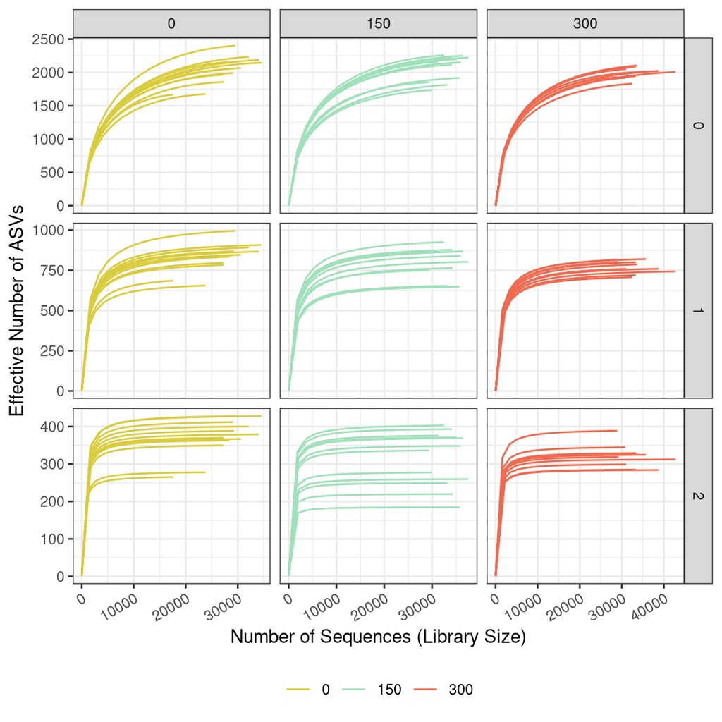

```r
# Plot it - Rarefaction Curve
iNEXT_manual_df %>%
  # Filter out rows that are calcaulted by rarefaction from iNEXT
  dplyr::filter(Method == "Rarefaction") %>%
  # Now, let's draw the plot, be sure to group by the samples if using geom_line!
  ggplot(aes(x = m, y= qD, color = n_level, group = names)) +
  geom_line() +
  # Facet with the n_level to see the samples better
  facet_grid(Order.q~n_level, scales = "free") +
  scale_color_manual(values = n_colors) +
  labs(x = "Number of Sequences (Library Size)",
       y = "Effective Number of ASVs") +
  theme_bw() +
  #guides(color = guide_legend(nrow = 2, byrow = TRUE)) +
  theme(legend.position = "bottom",
        axis.text.x = element_text(angle = 30, vjust = 1, hjust = 1),
        legend.title = element_blank())
```

Abundance-driven community differences seem to be most evident at the medium nitrogen level. There are 2 sample outliers for low ASVs in the Inverse Simpson plot for the low nitrogen treatments. I interpret this to mean these 2 samples have relatively more low-abundance taxa. In the final rarefaction plot presented below, these samples are shown to be from unplanted soils.

A scond rarefaction plot to see rarefaction patterns color coded by treatment, separated by nitrogen treatment.

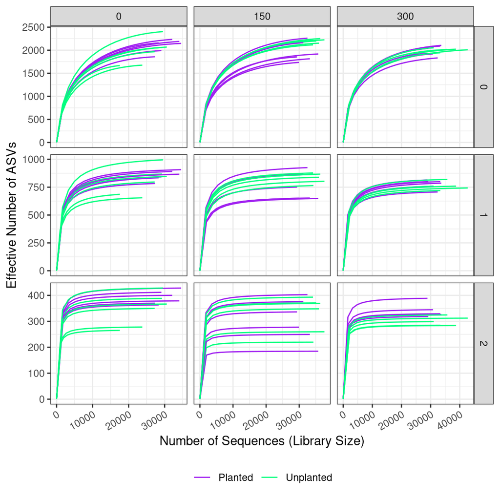

```r
# Plot it - Rarefaction Curve
iNEXT_manual_df %>%
  # Filter out rows that are calcaulted by rarefaction from iNEXT
  dplyr::filter(Method == "Rarefaction") %>%
  # Now, let's draw the plot, be sure to group by the samples if using geom_line!
  ggplot(aes(x = m, y= qD, color = planted, group = names)) +
  geom_line() +
  # Facet with the n_level to see the samples better
  facet_grid(Order.q~n_level, scales = "free") +
  scale_color_manual(values = planted_colors) +
  labs(x = "Number of Sequences (Library Size)",
       y = "Effective Number of ASVs") +
  theme_bw() +
  #guides(color = guide_legend(nrow = 2, byrow = TRUE)) +
  theme(legend.position = "bottom",
        axis.text.x = element_text(angle = 30, vjust = 1, hjust = 1),
        legend.title = element_blank())
```

Lets see how sampling date (“growth stage”) rarefaction plots, color coded by nitrogen level give us different information:

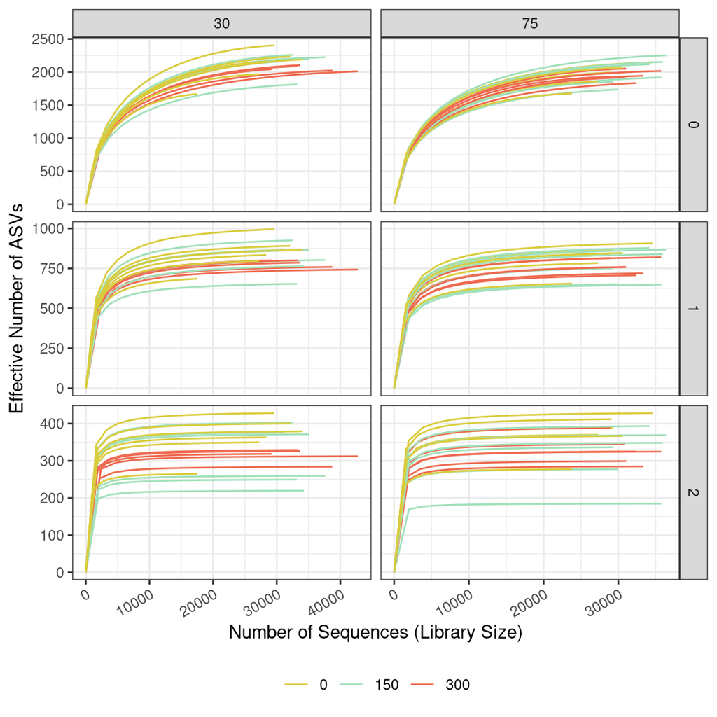

```r
# Plot it - Rarefaction Curve
iNEXT_manual_df_2 %>%
  # Filter out rows that are calcaulted by rarefaction from iNEXT
  dplyr::filter(Method == "Rarefaction") %>%
  # Now, let's draw the plot, be sure to group by the samples if using geom_line!
  ggplot(aes(x = m, y= qD, color = n_level, group = names)) +
  geom_line() +
  # Facet with the n_level to see the samples better
  facet_grid(Order.q~growth_stage, scales = "free") +
  scale_color_manual(values = n_colors) +
  labs(x = "Number of Sequences (Library Size)",
       y = "Effective Number of ASVs") +
  theme_bw() +
  #guides(color = guide_legend(nrow = 2, byrow = TRUE)) +
  theme(legend.position = "bottom",
        axis.text.x = element_text(angle = 30, vjust = 1, hjust = 1),
        legend.title = element_blank())
```

Rarefaction patterns for high nitrogen samples seem to group together, especially at the earlier time point. One sample outlier in the Inverse Simpson graph for the medium nitrogen treatment at the later time point becomes visible.

Next, lets see rarefaction patterns still color coded by nitrogen treatment, but comparing planted vs unplanted treatments.

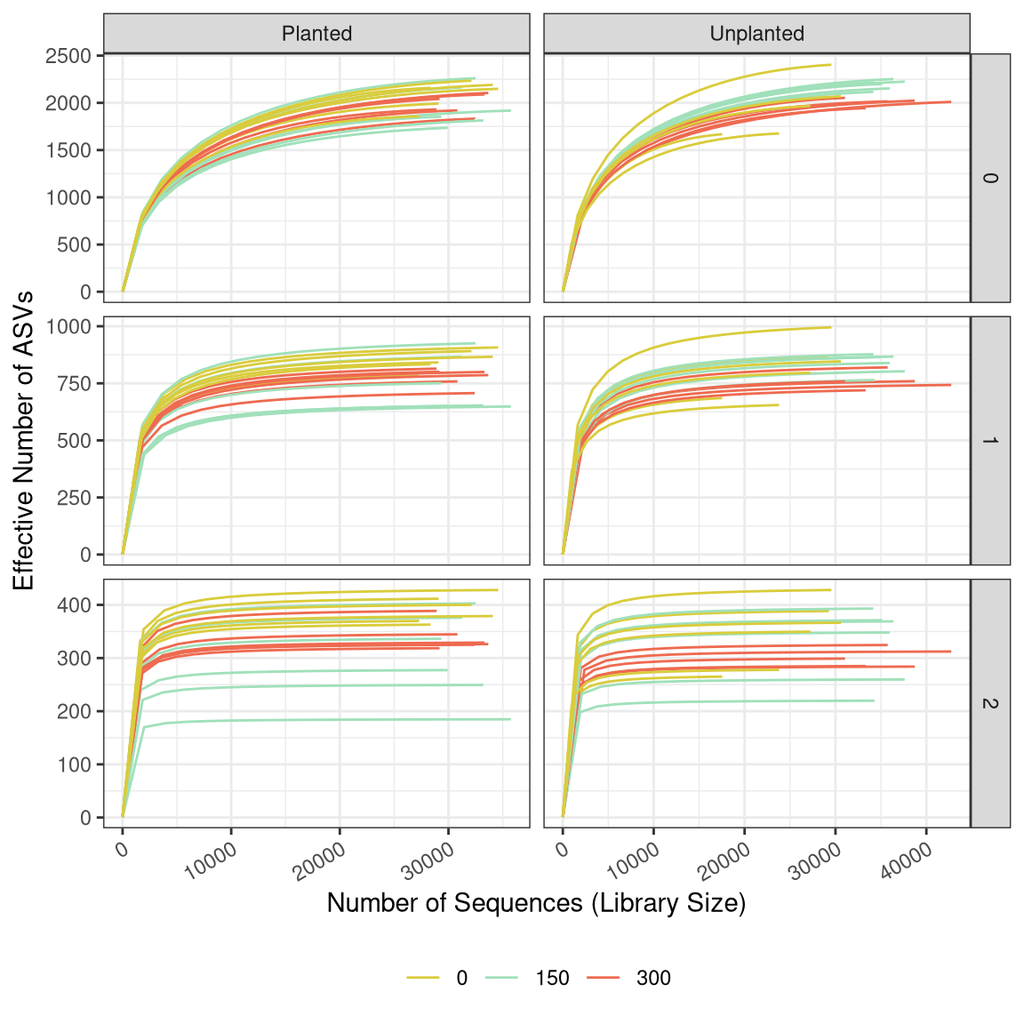

```r
# Plot it - Rarefaction Curve
iNEXT_manual_df_3 %>%
  # Filter out rows that are calculted by rarefaction from iNEXT
  dplyr::filter(Method == "Rarefaction") %>%
  # Now, let's draw the plot, be sure to group by the samples if using geom_line!
  ggplot(aes(x = m, y= qD, color = n_level, group = names)) +
  geom_line() +
  # Facet with the n_level to see the samples better
  facet_grid(Order.q~planted, scales = "free") +
  scale_color_manual(values = n_colors) +
  labs(x = "Number of Sequences (Library Size)",
       y = "Effective Number of ASVs") +
  theme_bw() +
  #guides(color = guide_legend(nrow = 2, byrow = TRUE)) +
  theme(legend.position = "bottom",
        axis.text.x = element_text(angle = 30, vjust = 1, hjust = 1),
        legend.title = element_blank())
```

Rarefaction patterns for high nitrogen samples still group together in planted and unplanted treatments. The sample outlier at the second time point in the Inverse Simpson plot discussed above appears to be from a planted treatment, with the lowest effective number of ASVs being from a planted, medium nitrogen treatment sample in this plot.

Finally, color code by sampling date and separate by treatment.

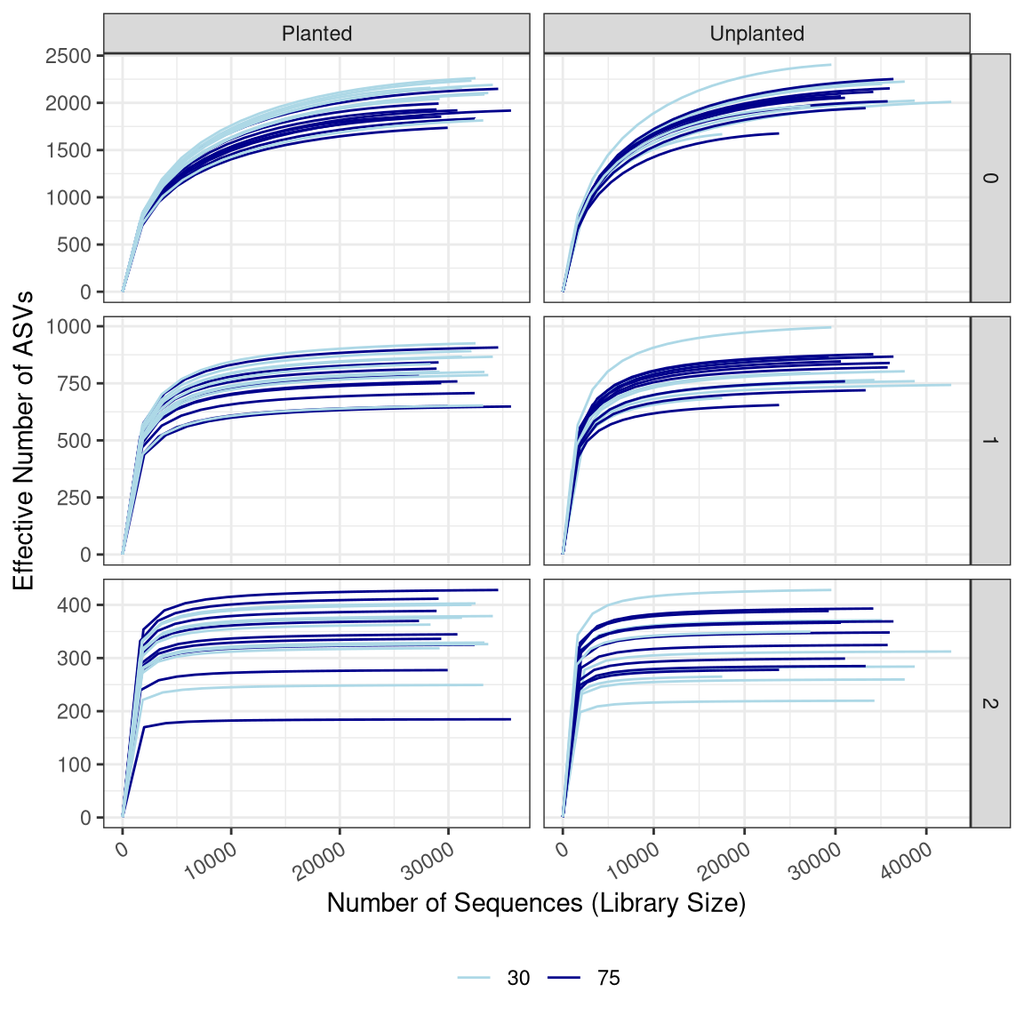

```r
# Plot it - Rarefaction Curve
iNEXT_manual_df_3 %>%
  # Filter out rows that are calculted by rarefaction from iNEXT
  dplyr::filter(Method == "Rarefaction") %>%
  # Now, let's draw the plot, be sure to group by the samples if using geom_line!
  ggplot(aes(x = m, y= qD, color = growth_stage, group = names)) +
  geom_line() +
  # Facet with the n_level to see the samples better
  facet_grid(Order.q~planted, scales = "free") +
  scale_color_manual(values = growth_stage_colors) +
  labs(x = "Number of Sequences (Library Size)",
       y = "Effective Number of ASVs") +
  theme_bw() +
  #guides(color = guide_legend(nrow = 2, byrow = TRUE)) +
  theme(legend.position = "bottom",
        axis.text.x = element_text(angle = 30, vjust = 1, hjust = 1),
        legend.title = element_blank())
```

Overall richness differs most evidently by time point in the planted treatments, with richness decreasing over time as expected by plant root mediated selection of microbes (via root exudation). There is also a nearly (althouh not entirely) bimodal distribution of richness rarefaction patterns for planted vs unplanted treatments at the medium nitrogen level. Species dominance seems to be influenced by nitrogen treatments and plant presence due to patterns in Inverse Simpson plots.

# Boxplots of Diversity

Now, let’s zoom in on a bit of a better view of the data by visualizing it in a boxplot…

```r
n_level_names <- c("Low N","Med N","High N")
names(n_level_names) <- c("0","50","300")

planted_names <- c ("Plant", "No Plant")
names(planted_names) <- c ("Planted", "Unplanted")

growth_stage_names <- c("Day 30","Day 75")
names(growth_stage_names) <- c("30","75")

# Make a dataframe
obs_div_df <-
  iNEXT_manual_df %>%
  dplyr::filter(Method == "Observed") %>%
  left_join(data.frame(n_level_names = n_level_names,
                       n_level = names(n_level_names)),
                       by = "n_level")
head(obs_div_df)
```

```
##         names     m   Method Order.q        qD    qD.LCL    qD.UCL        SC
## 1 SRR21916202 29262 Observed       0 2060.0000 2035.6625 2084.3375 0.9954899
## 2 SRR21916202 29262 Observed       1  867.5395  854.2282  880.8507 0.9954899
## 3 SRR21916202 29262 Observed       2  388.4869  375.6312  401.3425 0.9954899
## 4 SRR21916203 38724 Observed       0 2023.0000 2005.4316 2040.5684 0.9964367
## 5 SRR21916203 38724 Observed       1  759.3500  748.5984  770.1016 0.9964367
## 6 SRR21916203 38724 Observed       2  283.9289  274.7127  293.1450 0.9964367
##      SC.LCL    SC.UCL   planted n_level growth_stage rep input filtered
## 1 0.9946387 0.9963411 Unplanted       0           75   1 84301    72757
## 2 0.9946387 0.9963411 Unplanted       0           75   1 84301    72757
## 3 0.9946387 0.9963411 Unplanted       0           75   1 84301    72757
## 4 0.9957197 0.9971537 Unplanted     300           30   3 90262    78653
## 5 0.9957197 0.9971537 Unplanted     300           30   3 90262    78653
## 6 0.9957197 0.9971537 Unplanted     300           30   3 90262    78653
##   denoisedF denoisedR merged nochim perc_reads_retained n_colors n_level_names
## 1     63336     65789  35826  29386            34.85842  #D9CC3C         Low N
## 2     63336     65789  35826  29386            34.85842  #D9CC3C         Low N
## 3     63336     65789  35826  29386            34.85842  #D9CC3C         Low N
## 4     70184     72774  46001  38767            42.94941   coral2        High N
## 5     70184     72774  46001  38767            42.94941   coral2        High N
## 6     70184     72774  46001  38767            42.94941   coral2        High N
```

```r
obs_div_df_2 <-
  iNEXT_manual_df %>%
  dplyr::filter(Method == "Observed") %>%
  left_join(data.frame(planted_names = planted_names,
                      planted = names(planted_names)),
                       by = "planted")

head(obs_div_df_2)
```

```
##         names     m   Method Order.q        qD    qD.LCL    qD.UCL        SC
## 1 SRR21916202 29262 Observed       0 2060.0000 2035.6625 2084.3375 0.9954899
## 2 SRR21916202 29262 Observed       1  867.5395  854.2282  880.8507 0.9954899
## 3 SRR21916202 29262 Observed       2  388.4869  375.6312  401.3425 0.9954899
## 4 SRR21916203 38724 Observed       0 2023.0000 2005.4316 2040.5684 0.9964367
## 5 SRR21916203 38724 Observed       1  759.3500  748.5984  770.1016 0.9964367
## 6 SRR21916203 38724 Observed       2  283.9289  274.7127  293.1450 0.9964367
##      SC.LCL    SC.UCL   planted n_level growth_stage rep input filtered
## 1 0.9946387 0.9963411 Unplanted       0           75   1 84301    72757
## 2 0.9946387 0.9963411 Unplanted       0           75   1 84301    72757
## 3 0.9946387 0.9963411 Unplanted       0           75   1 84301    72757
## 4 0.9957197 0.9971537 Unplanted     300           30   3 90262    78653
## 5 0.9957197 0.9971537 Unplanted     300           30   3 90262    78653
## 6 0.9957197 0.9971537 Unplanted     300           30   3 90262    78653
##   denoisedF denoisedR merged nochim perc_reads_retained n_colors planted_names
## 1     63336     65789  35826  29386            34.85842  #D9CC3C      No Plant
## 2     63336     65789  35826  29386            34.85842  #D9CC3C      No Plant
## 3     63336     65789  35826  29386            34.85842  #D9CC3C      No Plant
## 4     70184     72774  46001  38767            42.94941   coral2      No Plant
## 5     70184     72774  46001  38767            42.94941   coral2      No Plant
## 6     70184     72774  46001  38767            42.94941   coral2      No Plant
```

```r
obs_div_df_3 <-
  iNEXT_manual_df %>%
  dplyr::filter(Method == "Observed") %>%
  left_join(data.frame(growth_stage_names = growth_stage_names,
                      growth_stage = names(growth_stage_names)),
                       by = "growth_stage")
head(obs_div_df_3)
```

```
##         names     m   Method Order.q        qD    qD.LCL    qD.UCL        SC
## 1 SRR21916202 29262 Observed       0 2060.0000 2035.6625 2084.3375 0.9954899
## 2 SRR21916202 29262 Observed       1  867.5395  854.2282  880.8507 0.9954899
## 3 SRR21916202 29262 Observed       2  388.4869  375.6312  401.3425 0.9954899
## 4 SRR21916203 38724 Observed       0 2023.0000 2005.4316 2040.5684 0.9964367
## 5 SRR21916203 38724 Observed       1  759.3500  748.5984  770.1016 0.9964367
## 6 SRR21916203 38724 Observed       2  283.9289  274.7127  293.1450 0.9964367
##      SC.LCL    SC.UCL   planted n_level growth_stage rep input filtered
## 1 0.9946387 0.9963411 Unplanted       0           75   1 84301    72757
## 2 0.9946387 0.9963411 Unplanted       0           75   1 84301    72757
## 3 0.9946387 0.9963411 Unplanted       0           75   1 84301    72757
## 4 0.9957197 0.9971537 Unplanted     300           30   3 90262    78653
## 5 0.9957197 0.9971537 Unplanted     300           30   3 90262    78653
## 6 0.9957197 0.9971537 Unplanted     300           30   3 90262    78653
##   denoisedF denoisedR merged nochim perc_reads_retained n_colors
## 1     63336     65789  35826  29386            34.85842  #D9CC3C
## 2     63336     65789  35826  29386            34.85842  #D9CC3C
## 3     63336     65789  35826  29386            34.85842  #D9CC3C
## 4     70184     72774  46001  38767            42.94941   coral2
## 5     70184     72774  46001  38767            42.94941   coral2
## 6     70184     72774  46001  38767            42.94941   coral2
##   growth_stage_names
## 1             Day 75
## 2             Day 75
## 3             Day 75
## 4             Day 30
## 5             Day 30
## 6             Day 30
```

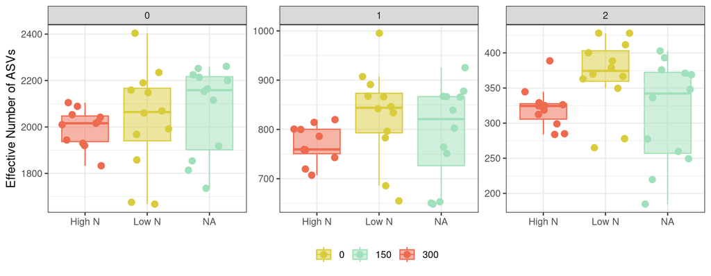

```r
# Boxplots by nitrogen level
# Boxplots by station
obs_div_df %>%
  ggplot(aes(x = n_level_names, y = qD, fill = n_level, color = n_level)) +
  facet_wrap(~Order.q, scales = "free") +
  geom_jitter(size = 2.5) +
  geom_boxplot(alpha = 0.5, outlier.shape = NA) +
  scale_color_manual(values = n_colors) +
  scale_fill_manual(values = n_colors) +
  labs(y = "Effective Number of ASVs") +
  theme_bw() +
  theme(legend.position = "bottom",
        axis.title.x = element_blank(),
        legend.title = element_blank())
```

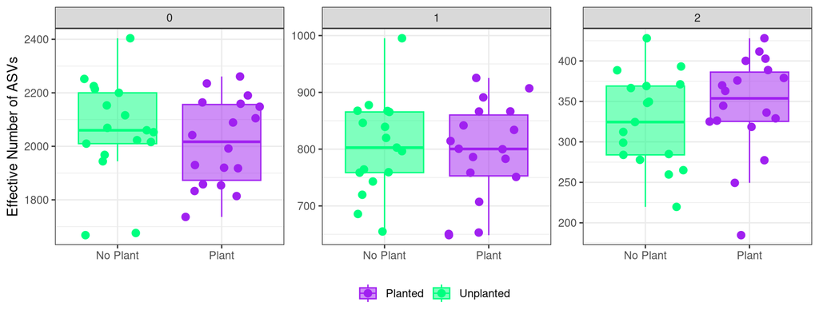

```r
# Boxplots by plant treatment
obs_div_df_2 %>%
  ggplot(aes(x = planted_names, y = qD, fill = planted, color = planted)) +
  facet_wrap(~Order.q, scales = "free") +
  geom_jitter(size = 2.5) +
  geom_boxplot(alpha = 0.5, outlier.shape = NA) +
  scale_color_manual(values = planted_colors) +
  scale_fill_manual(values = planted_colors) +
  labs(y = "Effective Number of ASVs") +
  theme_bw() +
  theme(legend.position = "bottom",
        axis.title.x = element_blank(),
        legend.title = element_blank())
```

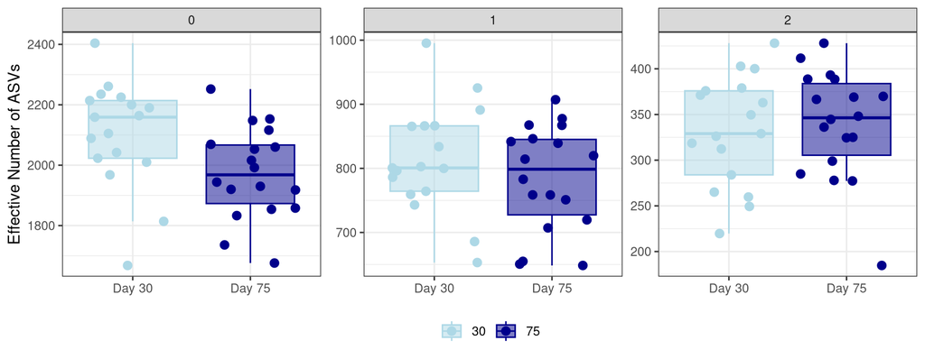

```r
# Boxplots by time point
obs_div_df_3 %>%
  ggplot(aes(x = growth_stage_names, y = qD, fill = growth_stage, color = growth_stage)) +
  facet_wrap(~Order.q, scales = "free") +
  geom_jitter(size = 2.5) +
  geom_boxplot(alpha = 0.5, outlier.shape = NA) +
  scale_color_manual(values = growth_stage_colors) +
  scale_fill_manual(values = growth_stage_colors) +
  labs(y = "Effective Number of ASVs") +
  theme_bw() +
  theme(legend.position = "bottom",
        axis.title.x = element_blank(),
        legend.title = element_blank())
```

# Environmental Variable Check

Applicable environmental variables are not available for this dataset. There may have been more environmental data collected, but the metadata was not available for download. The metadata csv used was constructed by inference for the purpose of this project. I did attempt to find a correlation between available variables, but the output was not informative (below).

```r
head(metadata_df)
```

```
##                   names   planted n_level growth_stage rep input filtered
## SRR21916202 SRR21916202 Unplanted       0           75   1 84301    72757
## SRR21916203 SRR21916203 Unplanted     300           30   3 90262    78653
## SRR21916205 SRR21916205 Unplanted     300           30   1 98609    85375
## SRR21916206 SRR21916206 Unplanted     150           30   3 98699    85615
## SRR21916207 SRR21916207 Unplanted     150           30   2 95172    82622
## SRR21916208 SRR21916208   Planted     300           75   3 92237    79185
##             denoisedF denoisedR merged nochim perc_reads_retained
## SRR21916202     63336     65789  35826  29386            34.85842
## SRR21916203     70184     72774  46001  38767            42.94941
## SRR21916205     77532     79587  50008  42868            43.47271
## SRR21916206     76055     78373  45951  37728            38.22531
## SRR21916207     72670     75130  42658  35255            37.04346
## SRR21916208     69693     72204  39858  30898            33.49849
```

```r
# Change growth stage and n_level columns back to being numeric
metadata_df$growth_stage <- as.numeric(metadata_df$growth_stage)
metadata_df$n_level <- as.numeric(metadata_df$n_level)

# Pull out environmental variables
env_df <-
  metadata_df %>%
  dplyr::select(names, n_level, growth_stage)
# inspect
head(env_df)
```

```
##                   names n_level growth_stage
## SRR21916202 SRR21916202       0           75
## SRR21916203 SRR21916203     300           30
## SRR21916205 SRR21916205     300           30
## SRR21916206 SRR21916206     150           30
## SRR21916207 SRR21916207     150           30
## SRR21916208 SRR21916208     300           75
```

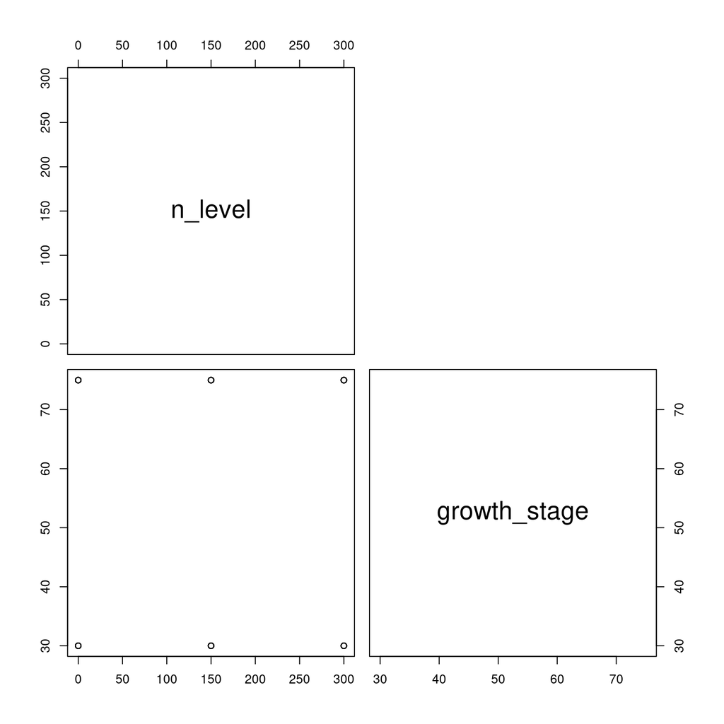

```r
# plot the correlations
pairs(dplyr::select(env_df, -names), upper.panel = NULL)
```

# Diversity vs Nitrogen Addition

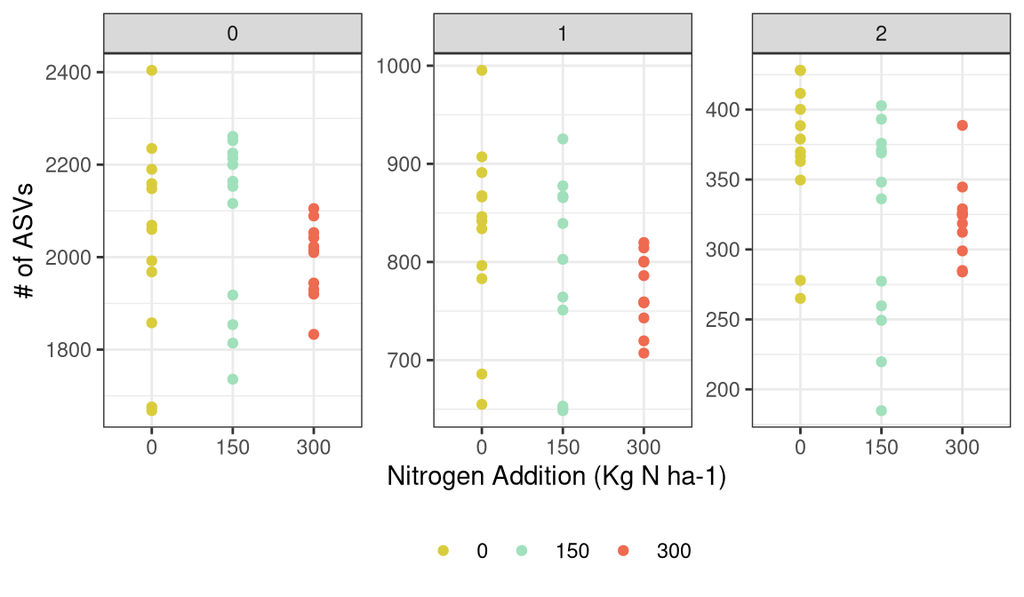

```r
iNEXT_manual_df %>%
  dplyr::filter(Method == "Observed") %>%
  ggplot(aes(x = n_level, y = qD)) +
  facet_wrap(.~Order.q, scales = "free") +
  geom_point(aes(color = n_level)) +
  stat_smooth(method = "lm", formula = y ~poly(x, 2)) +
  labs(x = "Nitrogen Addition (Kg N ha-1)", y = "# of ASVs") +
  scale_color_manual(values = n_colors) +
  theme_bw() +
  theme(legend.position = "bottom",
        legend.title = element_blank())
```

Interpretation: Richness ranges widely for samples in low (0 Kg N ha-1) and medium (150 Kg N ha-1) nitrogen additions and a high nitrogen addition results in intermediate levels of richness. The pattern generally holds when taxa dominance (abundance) is considered in the Shannon and Inverse Simpson plots.